# Credit Card Fraud Detection

1. logistic regression
2. XGBoost
3. Neural Network
4. Random Forests
5. Stacking of Random Forest, Neural Network and XGBoost

```python
# import libraries
import pandas as pd
import matplotlib.pyplot as plt
import numpy as np

from sklearn.preprocessing import StandardScaler
from sklearn.model_selection import train_test_split, GridSearchCV
from sklearn.metrics import classification_report, f1_score, make_scorer
from sklearn.linear_model import LogisticRegression

import plotly.express as px
import plotly.graph_objects as go

from sklearn.manifold import TSNE

import seaborn as sns

from joblib import dump, load, Parallel, delayed
from imblearn.over_sampling import SMOTE

from sklearn.model_selection import KFold, cross_val_score
from sklearn.ensemble import RandomForestClassifier

import xgboost as xgb


# Neural Network Requirements
import tensorflow as tf
from tensorflow.keras.models import Sequential
from tensorflow.keras import Model
from tensorflow.keras.layers import Dense
from tensorflow.keras.optimizers import Adam
from tensorflow.keras.callbacks import EarlyStopping
from tensorflow.keras.losses import BinaryCrossentropy

import os
```

```python
# Load the dataset
df = pd.read_csv('data/creditcard.csv')
df.head()
```

|  | Time | V1 | V2 | V3 | V4 | V5 | V6 | V7 | V8 | V9 | ... | V21 | V22 | V23 | V24 | V25 | V26 | V27 | V28 | Amount | Class |
| --- | --- | --- | --- | --- | --- | --- | --- | --- | --- | --- | --- | --- | --- | --- | --- | --- | --- | --- | --- | --- | --- |
| 0 | 0.0 | -1.359807 | -0.072781 | 2.536347 | 1.378155 | -0.338321 | 0.462388 | 0.239599 | 0.098698 | 0.363787 | ... | -0.018307 | 0.277838 | -0.110474 | 0.066928 | 0.128539 | -0.189115 | 0.133558 | -0.021053 | 149.62 | 0 |
| 1 | 0.0 | 1.191857 | 0.266151 | 0.166480 | 0.448154 | 0.060018 | -0.082361 | -0.078803 | 0.085102 | -0.255425 | ... | -0.225775 | -0.638672 | 0.101288 | -0.339846 | 0.167170 | 0.125895 | -0.008983 | 0.014724 | 2.69 | 0 |
| 2 | 1.0 | -1.358354 | -1.340163 | 1.773209 | 0.379780 | -0.503198 | 1.800499 | 0.791461 | 0.247676 | -1.514654 | ... | 0.247998 | 0.771679 | 0.909412 | -0.689281 | -0.327642 | -0.139097 | -0.055353 | -0.059752 | 378.66 | 0 |
| 3 | 1.0 | -0.966272 | -0.185226 | 1.792993 | -0.863291 | -0.010309 | 1.247203 | 0.237609 | 0.377436 | -1.387024 | ... | -0.108300 | 0.005274 | -0.190321 | -1.175575 | 0.647376 | -0.221929 | 0.062723 | 0.061458 | 123.50 | 0 |
| 4 | 2.0 | -1.158233 | 0.877737 | 1.548718 | 0.403034 | -0.407193 | 0.095921 | 0.592941 | -0.270533 | 0.817739 | ... | -0.009431 | 0.798278 | -0.137458 | 0.141267 | -0.206010 | 0.502292 | 0.219422 | 0.215153 | 69.99 | 0 |

5 rows × 31 columns

```python
df.shape
```

```
(284807, 31)
```

```python
df.isna().sum().sum()
```

```
0
```

```python
df.Class.value_counts()
```

```
Class
0    284315
1       492
Name: count, dtype: int64
```

```python
prop = sum(df.Class.values==1) / sum(df.Class.value_counts())
```

```python
print(f'Proportion of fraudilant data: {prop*100}%')
```

```
Proportion of fraudilant data: 0.1727485630620034%
```

We see that the dataset is highly unbalanced.

```python
df.describe()
```

|  | Time | V1 | V2 | V3 | V4 | V5 | V6 | V7 | V8 | V9 | ... | V21 | V22 | V23 | V24 | V25 | V26 | V27 | V28 | Amount | Class |
| --- | --- | --- | --- | --- | --- | --- | --- | --- | --- | --- | --- | --- | --- | --- | --- | --- | --- | --- | --- | --- | --- |
| count | 284807.000000 | 2.848070e+05 | 2.848070e+05 | 2.848070e+05 | 2.848070e+05 | 2.848070e+05 | 2.848070e+05 | 2.848070e+05 | 2.848070e+05 | 2.848070e+05 | ... | 2.848070e+05 | 2.848070e+05 | 2.848070e+05 | 2.848070e+05 | 2.848070e+05 | 2.848070e+05 | 2.848070e+05 | 2.848070e+05 | 284807.000000 | 284807.000000 |
| mean | 94813.859575 | 1.168375e-15 | 3.416908e-16 | -1.379537e-15 | 2.074095e-15 | 9.604066e-16 | 1.487313e-15 | -5.556467e-16 | 1.213481e-16 | -2.406331e-15 | ... | 1.654067e-16 | -3.568593e-16 | 2.578648e-16 | 4.473266e-15 | 5.340915e-16 | 1.683437e-15 | -3.660091e-16 | -1.227390e-16 | 88.349619 | 0.001727 |
| std | 47488.145955 | 1.958696e+00 | 1.651309e+00 | 1.516255e+00 | 1.415869e+00 | 1.380247e+00 | 1.332271e+00 | 1.237094e+00 | 1.194353e+00 | 1.098632e+00 | ... | 7.345240e-01 | 7.257016e-01 | 6.244603e-01 | 6.056471e-01 | 5.212781e-01 | 4.822270e-01 | 4.036325e-01 | 3.300833e-01 | 250.120109 | 0.041527 |
| min | 0.000000 | -5.640751e+01 | -7.271573e+01 | -4.832559e+01 | -5.683171e+00 | -1.137433e+02 | -2.616051e+01 | -4.355724e+01 | -7.321672e+01 | -1.343407e+01 | ... | -3.483038e+01 | -1.093314e+01 | -4.480774e+01 | -2.836627e+00 | -1.029540e+01 | -2.604551e+00 | -2.256568e+01 | -1.543008e+01 | 0.000000 | 0.000000 |
| 25% | 54201.500000 | -9.203734e-01 | -5.985499e-01 | -8.903648e-01 | -8.486401e-01 | -6.915971e-01 | -7.682956e-01 | -5.540759e-01 | -2.086297e-01 | -6.430976e-01 | ... | -2.283949e-01 | -5.423504e-01 | -1.618463e-01 | -3.545861e-01 | -3.171451e-01 | -3.269839e-01 | -7.083953e-02 | -5.295979e-02 | 5.600000 | 0.000000 |
| 50% | 84692.000000 | 1.810880e-02 | 6.548556e-02 | 1.798463e-01 | -1.984653e-02 | -5.433583e-02 | -2.741871e-01 | 4.010308e-02 | 2.235804e-02 | -5.142873e-02 | ... | -2.945017e-02 | 6.781943e-03 | -1.119293e-02 | 4.097606e-02 | 1.659350e-02 | -5.213911e-02 | 1.342146e-03 | 1.124383e-02 | 22.000000 | 0.000000 |
| 75% | 139320.500000 | 1.315642e+00 | 8.037239e-01 | 1.027196e+00 | 7.433413e-01 | 6.119264e-01 | 3.985649e-01 | 5.704361e-01 | 3.273459e-01 | 5.971390e-01 | ... | 1.863772e-01 | 5.285536e-01 | 1.476421e-01 | 4.395266e-01 | 3.507156e-01 | 2.409522e-01 | 9.104512e-02 | 7.827995e-02 | 77.165000 | 0.000000 |
| max | 172792.000000 | 2.454930e+00 | 2.205773e+01 | 9.382558e+00 | 1.687534e+01 | 3.480167e+01 | 7.330163e+01 | 1.205895e+02 | 2.000721e+01 | 1.559499e+01 | ... | 2.720284e+01 | 1.050309e+01 | 2.252841e+01 | 4.584549e+00 | 7.519589e+00 | 3.517346e+00 | 3.161220e+01 | 3.384781e+01 | 25691.160000 | 1.000000 |

8 rows × 31 columns

```python
df[df.Class==1].head()
```

|  | Time | V1 | V2 | V3 | V4 | V5 | V6 | V7 | V8 | V9 | ... | V21 | V22 | V23 | V24 | V25 | V26 | V27 | V28 | Amount | Class |
| --- | --- | --- | --- | --- | --- | --- | --- | --- | --- | --- | --- | --- | --- | --- | --- | --- | --- | --- | --- | --- | --- |
| 541 | 406.0 | -2.312227 | 1.951992 | -1.609851 | 3.997906 | -0.522188 | -1.426545 | -2.537387 | 1.391657 | -2.770089 | ... | 0.517232 | -0.035049 | -0.465211 | 0.320198 | 0.044519 | 0.177840 | 0.261145 | -0.143276 | 0.00 | 1 |
| 623 | 472.0 | -3.043541 | -3.157307 | 1.088463 | 2.288644 | 1.359805 | -1.064823 | 0.325574 | -0.067794 | -0.270953 | ... | 0.661696 | 0.435477 | 1.375966 | -0.293803 | 0.279798 | -0.145362 | -0.252773 | 0.035764 | 529.00 | 1 |
| 4920 | 4462.0 | -2.303350 | 1.759247 | -0.359745 | 2.330243 | -0.821628 | -0.075788 | 0.562320 | -0.399147 | -0.238253 | ... | -0.294166 | -0.932391 | 0.172726 | -0.087330 | -0.156114 | -0.542628 | 0.039566 | -0.153029 | 239.93 | 1 |
| 6108 | 6986.0 | -4.397974 | 1.358367 | -2.592844 | 2.679787 | -1.128131 | -1.706536 | -3.496197 | -0.248778 | -0.247768 | ... | 0.573574 | 0.176968 | -0.436207 | -0.053502 | 0.252405 | -0.657488 | -0.827136 | 0.849573 | 59.00 | 1 |
| 6329 | 7519.0 | 1.234235 | 3.019740 | -4.304597 | 4.732795 | 3.624201 | -1.357746 | 1.713445 | -0.496358 | -1.282858 | ... | -0.379068 | -0.704181 | -0.656805 | -1.632653 | 1.488901 | 0.566797 | -0.010016 | 0.146793 | 1.00 | 1 |

5 rows × 31 columns

```python
# removing the time variable
df.drop('Time', axis=1, inplace=True)
```

```python
scaler = StandardScaler()
df['Amount'] = scaler.fit_transform(df['Amount'].values.reshape(-1, 1))    # Standardizing the amount dataset

# Split into feautures X and target y
X = df.drop('Class', axis=1)
y = df['Class']

# Split into train and test data
X_train, X_test, y_train, y_test = train_test_split(
    X,
    y,
    test_size=0.3,
    random_state=42
)
```

## 1. Exploratory Data Analysis on the Training Data

### 1.1 Plotting the first two and three principal components

```python
df_train = X_train.copy()
df_train['Class'] = y_train.values
X_train, X_test = X_train.values, X_test.values
y_train, y_test = y_train.values, y_test.values
```

```python
X_train[:,-1]
```

```
array([-0.34923131,  4.42160499, -0.05337293, ..., -0.33747693,
       -0.34923131,  0.09855435])
```

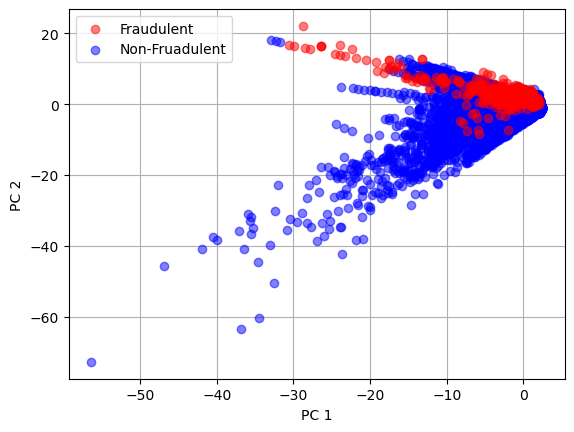

```python
#plt.title('First Two Principle Components')
first_pc = X_train[:,0]
second_pc = X_train[:, 1]
plt.scatter(first_pc[y_train==1], second_pc[y_train==1], label='Fraudulent', alpha=0.5, zorder=3, color='red')
plt.scatter(first_pc[y_train==0], second_pc[y_train==0], label='Non-Fruadulent', alpha=0.5, zorder=2, color='blue')
plt.grid(zorder=1)
plt.legend()
plt.xlabel('PC 1')
plt.ylabel('PC 2')
plt.savefig('Two_pcs.png', dpi=300)
plt.show()
```

```python
x_vals = X_train[:,0]
y_vals = X_train[:,1]
z_vals = X_train[:,2]
labels = y_train

# Colour and opacity
colors = np.where(labels == 1, 'rgba(220, 20, 60, 0.6)', 'rgba(0, 0, 128, 0.6)')  # Crimson / Navy with alpha

# Create scatter trace
fig = go.Figure(data=[go.Scatter3d(
    x=x_vals, y=y_vals, z=z_vals,
    mode='markers',
    marker=dict(
        size=5,
        color=colors,
        line=dict(width=0),
        opacity=0.6
    )
)])


fig.update_layout(
    #title=dict(text='First Three Principal Components', x=0.5, font=dict(size=18)),
    scene=dict(
        xaxis=dict(title='PC 1', showgrid=True, gridcolor='lightgrey', zeroline=False),
        yaxis=dict(title='PC 2', showgrid=True, gridcolor='lightgrey', zeroline=False),
        zaxis=dict(title='PC 3', showgrid=True, gridcolor='lightgrey', zeroline=False),
        bgcolor='white',
        aspectmode='cube'
    ),
    margin=dict(l=0, r=0, t=40, b=0),
    showlegend=False,
    width=750,
    height=600
)

fig.write_image('three_pcs.png', scale=2)
fig.show()
```

[output not shown]

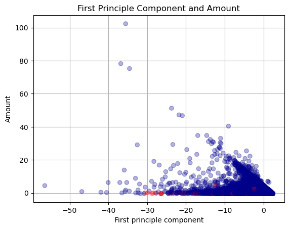

```python
plt.title('First Principle Component and Amount')
plt.scatter(X_train[:,0], X_train[:, -1], c=['red' if x==1 else 'darkblue' for x in y_train], alpha=0.3, zorder=2)
plt.grid(zorder=1)
plt.xlabel('First principle component')
plt.ylabel('Amount')
plt.show()
```

```python
# Subsample if data is large (t-SNE is computationally heavy)
try:
    X_tsne, y_sub = load('tsne_result.joblib')
except:
    np.random.seed(42)
    n_samples = 50000
    idx = np.random.choice(len(X_train), n_samples, replace=False)
    X_sub = X_train[idx]
    y_sub = y_train[idx]

    # Compute t-SNE
    tsne = TSNE(
        n_components=2,
        perplexity=30,   # Default=30, adjust for dense/sparse data
        random_state=42,
        n_iter=1000      # Increase for better convergence
    )
    X_tsne = tsne.fit_transform(X_sub)

    dump((X_tsne, y_sub), 'tsne_result.joblib')
```

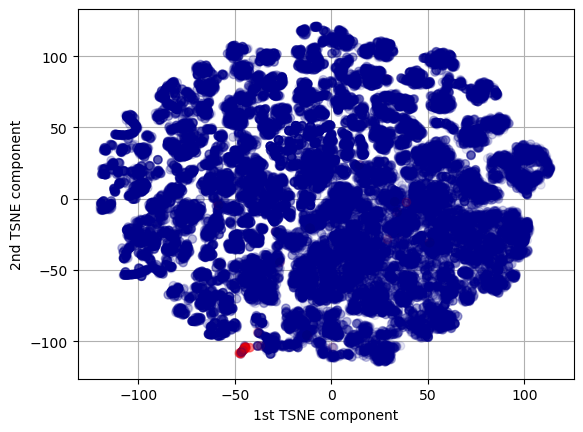

```python
#plt.title('2D TSNE')
plt.scatter(X_tsne[:, 0], X_tsne[:, 1], c=['red' if x==1 else 'darkblue' for x in y_sub], alpha=0.1, zorder=2)
plt.grid(zorder=1)
plt.xlabel('1st TSNE component')
plt.ylabel('2nd TSNE component')
plt.savefig('tsne.png', dpi=300)
plt.show()
```

[figure not shown]

```python
features = ['V1', 'V2', 'V3', 'V4', 'V5', 'V6']

# Create figure with 2 columns and 3 rows
fig, axes = plt.subplots(3, 2, figsize=(14, 16))
#fig.suptitle('Feature Distributions by Class', y=1.02, fontsize=16)

# Custom colors
palette = {0: 'skyblue', 1: 'coral'}

for i, feature in enumerate(features):
    row, col = i // 2, i % 2
    ax = axes[row, col]

    sns.histplot(
        data=df,
        x=feature,
        hue='Class',
        palette=palette,
        alpha=0.6,
        kde=True,
        bins=50,
        stat='density',  # Normalize to probabilities
        common_norm=False,  # Normalize each class independently
        ax=ax
    )

    ax.set_title(f'Density of {feature}', pad=12)
    ax.set_xlabel('')
    ax.grid(alpha=0.2)
    ax.legend(title='Class', labels=['Non-Fraud', 'Fraud'])

plt.tight_layout()
plt.savefig('feature_distributions.png', dpi=300)
plt.show()
```

## 2. Logistic Regression

5-fold cross validation will be done for logistic regression to tune the lambda coefficient of the L2 regularisation.

```python
np.arange(0.1, 1, 0.1)
```

```
array([0.1, 0.2, 0.3, 0.4, 0.5, 0.6, 0.7, 0.8, 0.9])
```

```python
n_splits = 5
kf  = KFold(n_splits=n_splits, random_state=42, shuffle=True)
lambdas = np.logspace(-3, 3, 100)  # Hyper parameters to optimise

# store the fold results,corresponding to the probability threshold that yields the
# highest avererage cross val score, for each hyper parameter value
cv_results = np.zeros((len(lambdas), n_splits))


try:
    cv_results = load('cv_results.joblib')
except:
    for j, l in enumerate(lambdas):

        prob_thresholds = np.arange(0.1, 1, 0.1)
        cv_results_per_prob = np.zeros((len(prob_thresholds), n_splits))     # stores the cv results for each probability threshold

        for i, (train_idx, test_idx) in enumerate(kf.split(X_train, y_train)):

            X_train_fold, X_test_fold = X_train[train_idx], X_train[test_idx]
            y_train_fold, y_test_fold = y_train[train_idx], y_train[test_idx]

            lr = LogisticRegression(C=1./l)
            lr.fit(X_train_fold, y_train_fold)
            pred_prob = lr.predict_proba(X_test_fold)[:, 1]
            f1_scores = np.array([f1_score(y_test_fold, pred_prob > x) for x in prob_thresholds])
            cv_results_per_prob[:, i] = f1_scores

        arg_prob = np.argmax(np.mean(cv_results_per_prob, axis=1))# probability threshold with the best cv score
        cv_results[j, :] = cv_results_per_prob[arg_prob, :]

    dump(cv_results, 'cv_results.joblib')
```

```python
cv_mean_var = np.c_[(np.mean(cv_results, axis=1), np.std(cv_results, axis=1, ddof=1)/np.sqrt(n_splits))]
```

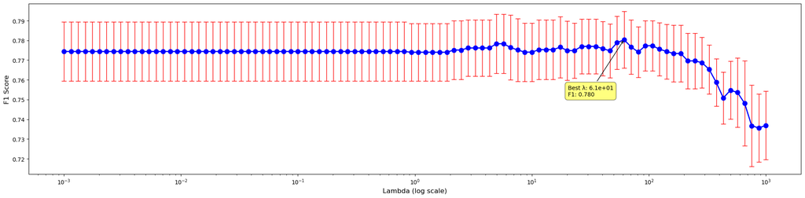

```python
plt.figure(figsize=(20, 5))

# Plot main line with points
plt.semilogx(lambdas, cv_mean_var[:, 0], 'o-', color='b', linewidth=2, markersize=8, label='Mean F1-score', zorder=2)

# Add error bars
plt.errorbar(lambdas, cv_mean_var[:, 0], yerr=cv_mean_var[:, 1], fmt='none',
             ecolor='red', elinewidth=1, capsize=4, zorder=1)

# Formatting
plt.xlabel('Lambda (log scale)', fontsize=12)
plt.ylabel('F1 Score', fontsize=12)
#plt.title('Cross-Validation Performance', fontsize=14)


# Highlight best lambda
best_idx = np.argmax(cv_mean_var[:, 0])
plt.annotate(f'Best λ: {lambdas[best_idx]:.1e}\nF1: {cv_mean_var[:, 0][best_idx]:.3f}',
             xy=(lambdas[best_idx], cv_mean_var[:, 0][best_idx]),
             xytext=(-100, -100), textcoords='offset points',
             bbox=dict(boxstyle='round,pad=0.5', fc='yellow', alpha=0.5),
             arrowprops=dict(arrowstyle='->'))

plt.tight_layout()
plt.savefig('logreg.png', dpi=300)
plt.show()
```

From this plot It is evident that there is not significant improvement in using L2 reguralisation in logistic regression. A plot shall now be constructed indicating the logistic regression cross validation scores for each probability threshold.

```python
n_splits = 5
kf = KFold(n_splits=n_splits, random_state=123, shuffle=True)
prob_thresholds = np.arange(0.05, 0.6, 0.05)

cv_result = np.zeros((n_splits, len(prob_thresholds)))
for i, (train_idx, test_idx) in enumerate(kf.split(X_train, y_train)):
    X_train_fold, X_test_fold = X_train[train_idx], X_train[test_idx]
    y_train_fold, y_test_fold = y_train[train_idx], y_train[test_idx]

    lr = LogisticRegression()
    lr.fit(X_train_fold, y_train_fold)
    cv_result[i,: ] = np.array([f1_score(y_test_fold, lr.predict_proba(X_test_fold)[:,1] > prob) for prob in prob_thresholds])

# Unpack results
means = np.mean(cv_result, axis=0)
std = np.std(cv_result, axis=0, ddof=1)/np.sqrt(n_splits)
```

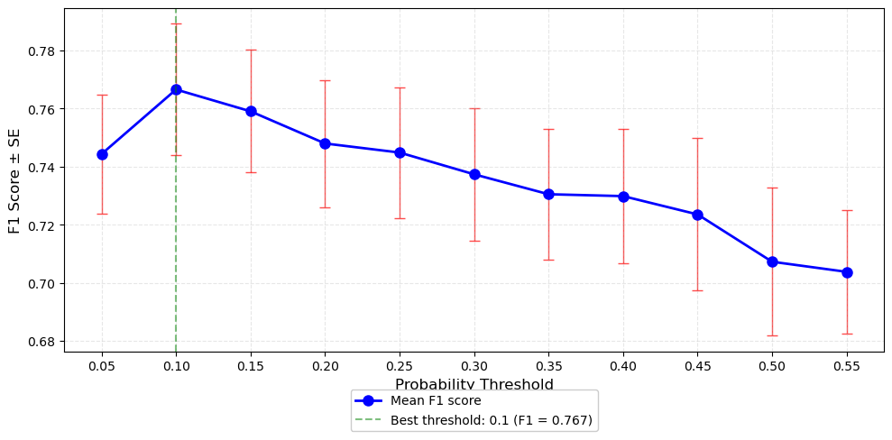

```python
plt.figure(figsize=(10, 5))

# Plot main line with points
plt.plot(prob_thresholds, means, 'o-', color='b', linewidth=2,
         markersize=8, label='Mean F1 score', zorder=2)

# Add error bars (standard error)
plt.errorbar(prob_thresholds, means, yerr=std, fmt='none',
             ecolor='red', elinewidth=1, capsize=4, alpha=0.7, zorder=1)

# Formatting
plt.xlabel('Probability Threshold', fontsize=12)
plt.ylabel('F1 Score ± SE', fontsize=12)
#plt.title('F1 Score vs. Classification Threshold (5-fold CV)', fontsize=14)
plt.grid(True, linestyle='--', alpha=0.3)

# Highlight best threshold
best_idx = np.argmax(means)
best_thresh = prob_thresholds[best_idx]
best_score = means[best_idx]

# Add dashed line at best threshold
plt.axvline(x=best_thresh, color='g', linestyle='--', alpha=0.5,
            label=f'Best threshold: {best_thresh:.1f} (F1 = {best_score:.3f})')

plt.xticks(prob_thresholds)  # Show all tested thresholds
plt.legend(loc='lower center', bbox_to_anchor=(0.5, -0.25), framealpha=1)
plt.tight_layout()
plt.savefig('logreg_threshold.png', dpi=300)
plt.show()
```

```python
chosen_prob_threshold=0.1
```

### 2.2 Logistic Regression with balanced class weights

```python
np.random.seed(123)

n_splits = 5
kf = KFold(n_splits=n_splits, random_state=123, shuffle=True)
prob_thresholds = np.arange(0.05, 0.8, 0.05)

cv_result = np.zeros((n_splits, len(prob_thresholds)))
for i, (train_idx, test_idx) in enumerate(kf.split(X_train, y_train)):
    X_train_fold, X_test_fold = X_train[train_idx], X_train[test_idx]
    y_train_fold, y_test_fold = y_train[train_idx], y_train[test_idx]

    lr = LogisticRegression(class_weight='balanced', max_iter=1000)
    lr.fit(X_train_fold, y_train_fold)
    cv_result[i,: ] = np.array([f1_score(y_test_fold, lr.predict_proba(X_test_fold)[:,1] > prob) for prob in prob_thresholds])

# Unpack results
means = np.mean(cv_result, axis=0)
std = np.std(cv_result, axis=0, ddof=1)/np.sqrt(n_splits)
```

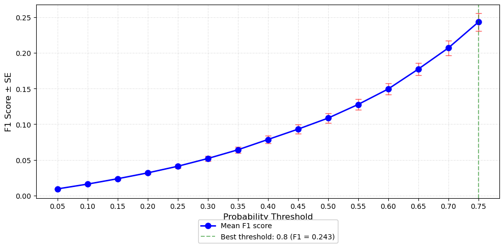

```python
plt.figure(figsize=(10, 5))

# Plot main line with points
plt.plot(prob_thresholds, means, 'o-', color='b', linewidth=2,
         markersize=8, label='Mean F1 score', zorder=2)

# Add error bars (standard error)
plt.errorbar(prob_thresholds, means, yerr=std, fmt='none',
             ecolor='red', elinewidth=1, capsize=4, alpha=0.7, zorder=1)

# Formatting
plt.xlabel('Probability Threshold', fontsize=12)
plt.ylabel('F1 Score ± SE', fontsize=12)
#plt.title('F1 Score vs. Classification Threshold (5-fold CV)', fontsize=14)
plt.grid(True, linestyle='--', alpha=0.3)

# Highlight best threshold
best_idx = np.argmax(means)
best_thresh = prob_thresholds[best_idx]
best_score = means[best_idx]

# Add dashed line at best threshold
plt.axvline(x=best_thresh, color='g', linestyle='--', alpha=0.5,
            label=f'Best threshold: {best_thresh:.1f} (F1 = {best_score:.3f})')

plt.xticks(prob_thresholds)  # Show all tested thresholds
plt.legend(loc='lower center', bbox_to_anchor=(0.5, -0.25), framealpha=1)
plt.tight_layout()
plt.savefig('logreg_prob_weighted.png', dpi=300)
plt.show()
```

```python
np.random.seed(123)
lr_tuned = LogisticRegression(random_state=42)
lr_tuned.fit(X_train, y_train)
lr_tuned_pred = lr_tuned.predict_proba(X_test)[:, 1] > chosen_prob_threshold
print(classification_report(y_test, lr_tuned_pred))
```

```
              precision    recall  f1-score   support

           0       1.00      1.00      1.00     85307
           1       0.80      0.80      0.80       136

    accuracy                           1.00     85443
   macro avg       0.90      0.90      0.90     85443
weighted avg       1.00      1.00      1.00     85443
```

### 3. Feed Forward Neural Network

In order to find a good architecture for the FNN the following hyper parameters are optimised:

1. learning rate
2. hidden units on its hidden layer
3. number of hidden layers
4. probability threshold

```python
# for each number of hidden layers number of units on the hidden layer the Cross Validation F1 mean and standard error is stored
param_dist = {
    'learning_rate': [1e-2, 1e-3, 1e-4],
    'hidden_units': [32, 64, 128, 256],
    'num_layers': [2, 3, 4, 5],
    'prob_thresholds': [0.05, 0.1, 0.2, 0.3, 0.4, 0.5]
}

n_splits = 5
kf  = KFold(n_splits=n_splits, random_state=42, shuffle=True)

def cv_results(num_layers, num_units):

    best_mean, best_std, best_learning_rate, best_prob_threshold = -1, None, None, None
    for learning_rate in param_dist['learning_rate']:
            print(f'at learning rate {learning_rate}')

            # storte the f1 score for the specific split and the probability threshold
            f1_scores_fold_prob = np.zeros((n_splits, len(param_dist['prob_thresholds'])))
            for i, (train_idx, test_idx) in enumerate(kf.split(X_train, y_train)):

                X_train_fold, X_test_fold = X_train[train_idx], X_train[test_idx]
                y_train_fold, y_test_fold = y_train[train_idx], y_train[test_idx]

                model =  Sequential()
                for _ in range(num_layers):
                    model.add(Dense(num_units, activation='relu'))
                model.add(Dense(1, activation='sigmoid'))
                optimizer = Adam(learning_rate=learning_rate)
                model.compile(optimizer=optimizer,
                              loss='binary_crossentropy',
                              metrics=['accuracy'])

                early_stopping = EarlyStopping(
                    monitor='val_loss',
                    patience=5, # number of epochs with no improvement
                    restore_best_weights=True,
                    min_delta=0.0001, # minimum change to quantify improvement
                    mode='min'        # lower loss is better
                )

                history = model.fit(
                    X_train_fold, y_train_fold,
                    validation_data = (X_test_fold, y_test_fold),
                    epochs=100,
                    batch_size=64,
                    callbacks=[early_stopping],
                    verbose=0
                )

                pred_prob = model.predict(X_test_fold).flatten()
                f1_scores = np.array([f1_score(y_test_fold, pred_prob > x) for x in param_dist['prob_thresholds']])
                f1_scores_fold_prob[i, :] = f1_scores

            if np.max(np.mean(f1_scores_fold_prob, axis=0)) > best_mean:
                 best_mean_idx =  np.argmax(np.mean(f1_scores_fold_prob, axis=0))
                 best_mean = np.mean(f1_scores_fold_prob, axis=0)[best_mean_idx]
                 best_std = np.std(f1_scores_fold_prob[:, best_mean_idx], ddof=1) / np.sqrt(n_splits)
                 best_learning_rate = learning_rate
                 best_prob_threshold = param_dist['prob_thresholds'][np.argmax(np.mean(f1_scores_fold_prob, axis=0))]

    return np.array([best_mean, best_std, best_learning_rate, best_prob_threshold])

if os.path.exists('nn_cv_results.joblib'):
    nn_cv_results = load('nn_cv_results.joblib')
else:
    # the last dimenstion stores the mean, std error and correpsonding learning rate and probability threshold
    nn_cv_results = np.zeros((len(param_dist['num_layers']), len(param_dist['hidden_units']), 4))
    for i, num_layers in enumerate(param_dist['num_layers']):
        for j, num_units in enumerate(param_dist['hidden_units']):
            print(f'Currently at num_layers {(i, num_layers)} and num_units {j, num_units}')
            nn_cv_results[i, j, :] = cv_results(num_layers, num_units)

    dump(nn_cv_results, 'nn_cv_results.joblib')
```

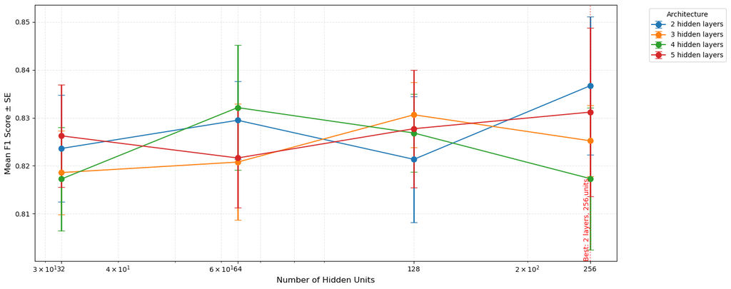

```python
num_layers_list = param_dist['num_layers']
hidden_units_list = param_dist['hidden_units']

# Create figure
plt.figure(figsize=(15, 6))

# Plot each layer configuration
for i, num_layers in enumerate(num_layers_list):
    # Extract means and standard errors
    means = nn_cv_results[i, :, 0]  # Mean F1 scores
    std_errs = nn_cv_results[i, :, 1]  # Standard errors

    plt.errorbar(
        x=hidden_units_list,
        y=means,
        yerr=std_errs,
        fmt='-o',
        label=f'{num_layers} hidden layers',
        capsize=5,
        elinewidth=2,
        markersize=8
    )

# Formatting
plt.xscale('log')
plt.xticks(hidden_units_list, labels=hidden_units_list)
plt.xlabel('Number of Hidden Units', fontsize=12)
plt.ylabel('Mean F1 Score ± SE', fontsize=12)
#plt.title('Model Performance by Architecture', fontsize=14)
plt.grid(True, which='both', linestyle='--', alpha=0.3)
plt.legend(title='Architecture', bbox_to_anchor=(1.05, 1), loc='upper left')

# Highlight best configuration
best_idx = np.unravel_index(np.argmax(nn_cv_results[:, :, 0]), nn_cv_results[:, :, 0].shape)
best_units = hidden_units_list[best_idx[1]]
best_layers = num_layers_list[best_idx[0]]
plt.axvline(x=best_units, color='red', linestyle=':', alpha=0.5)
plt.text(best_units, plt.ylim()[0],
         f'Best: {best_layers} layers, {best_units} units',
         rotation=90, va='bottom', ha='right', color='red')

plt.tight_layout()
plt.savefig('FNN_arch_unweighted.png', dpi=300)
plt.show()
```

Using the 1 standard error rule our chosen model is a neural network with 2 hidden layers with 32 neurons on each hidden layer.

```python
# obtaining the learning rate which yielded the best F1-score for the fold
num_layers = 2
num_units = 32
learning_rate, prob_threshold = nn_cv_results[0, 0, 2:]
print(f'learning rate: {learning_rate}')
print(f'probability threshold: {prob_threshold}')
```

```
learning rate: 0.001
probability threshold: 0.3
```

```python
# plotting the f1 scores for different probability thresholds
np.random.seed(123)
prob_thresholds = np.arange(0.05, 0.6, 0.05)
n_splits = 5
kf  = KFold(n_splits=n_splits, random_state=123, shuffle=True)
f1_scores_fold_prob = np.zeros((n_splits, len(prob_thresholds)))
for i, (train_idx, test_idx) in enumerate(kf.split(X_train, y_train)):

    X_train_fold, X_test_fold = X_train[train_idx], X_train[test_idx]
    y_train_fold, y_test_fold = y_train[train_idx], y_train[test_idx]

    balanced_model = Sequential()
    for _ in range(num_layers):
        balanced_model.add(Dense(num_units, activation='relu'))
    balanced_model.add(Dense(1, activation='sigmoid'))
    optimizer = Adam(learning_rate=learning_rate)
    balanced_model.compile(optimizer=optimizer,
                    loss='binary_crossentropy',
                    metrics=['accuracy'])

    early_stopping = EarlyStopping(
        monitor='val_loss',
        patience=5,                 # number of epochs with no improvement
        restore_best_weights=True,
        min_delta=0.0001,           # minimum change to quantify improvement
        mode='min'                  # lower loss is better
    )

    history = balanced_model.fit(
        X_train_fold, y_train_fold,
        validation_data = (X_test_fold, y_test_fold),
        epochs=100,
        batch_size=64,
        callbacks=[early_stopping],
        verbose=0
    )

    pred_prob = balanced_model.predict(X_test_fold).flatten()
    f1_scores = np.array([f1_score(y_test_fold, pred_prob > x) for x in prob_thresholds])
    f1_scores_fold_prob[i, :] = f1_scores
```

```
1247/1247 ━━━━━━━━━━━━━━━━━━━━ 1s 524us/step
1247/1247 ━━━━━━━━━━━━━━━━━━━━ 1s 531us/step
1247/1247 ━━━━━━━━━━━━━━━━━━━━ 1s 549us/step
1247/1247 ━━━━━━━━━━━━━━━━━━━━ 1s 634us/step
1246/1246 ━━━━━━━━━━━━━━━━━━━━ 1s 706us/step
```

```python
means = np.mean(f1_scores_fold_prob, axis=0)
stderr = np.std(f1_scores_fold_prob, axis=0, ddof=1) / np.sqrt(n_splits)
```

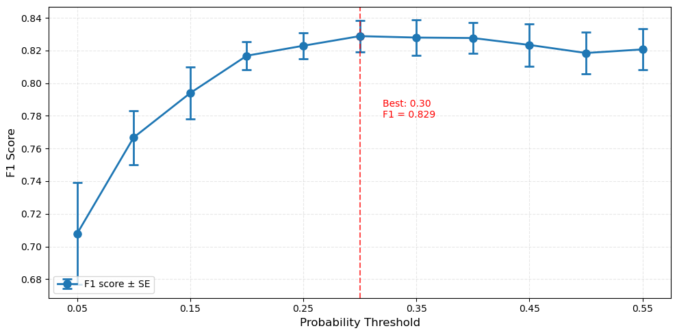

```python
plt.figure(figsize=(10, 5))

# Main plot with error bars
plt.errorbar(prob_thresholds, means, yerr=stderr,
             fmt='-o', color='#1f77b4',
             linewidth=2, markersize=8,
             capsize=5, capthick=2,
             label='F1 score ± SE')

# Highlight best threshold
best_idx = np.argmax(means)
plt.axvline(x=prob_thresholds[best_idx], color='red', linestyle='--', alpha=0.7)
plt.plot(prob_thresholds[best_idx], means[best_idx], 'ro', markersize=8)

# Text annotation for best point
plt.text(prob_thresholds[best_idx]+0.02, means[best_idx]-0.05,
         f'Best: {prob_thresholds[best_idx]:.2f}\nF1 = {means[best_idx]:.3f}',
         color='red')

# Formatting
plt.xlabel('Probability Threshold', fontsize=12)
plt.ylabel('F1 Score', fontsize=12)
#plt.title('Optimal Threshold Selection', fontsize=14)
plt.xticks(np.arange(min(prob_thresholds), max(prob_thresholds)+0.1, 0.1))
plt.grid(True, linestyle='--', alpha=0.3)
plt.legend(loc='lower left')

plt.tight_layout()
plt.savefig('FNN_thresh.png', dpi=300)
plt.show()
```

```python
best_prob_threshold = 0.3
```

#### (b) FNN with adjusted loss function to account for class imbalance

```python
# for each number of hidden layers number of units on the hidden layer the Cross Validation F1 mean and standard error is stored
param_dist = {
    'learning_rate': [1e-2, 1e-3, 1e-4],
    'hidden_units': [32, 64, 128, 256],
    'num_layers': [2, 3, 4, 5],
    'prob_thresholds': [0.05, 0.1, 0.2, 0.3, 0.4, 0.5]
}

n_splits = 5
kf  = KFold(n_splits=n_splits, random_state=42, shuffle=True)

def cv_results(num_layers, num_units):

    best_mean, best_std, best_learning_rate, best_prob_threshold = -1, None, None, None
    for learning_rate in param_dist['learning_rate']:
            print(f'at learning rate {learning_rate}')

            # storte the f1 score for the specific split and the probability threshold
            f1_scores_fold_prob = np.zeros((n_splits, len(param_dist['prob_thresholds'])))
            for i, (train_idx, test_idx) in enumerate(kf.split(X_train, y_train)):

                X_train_fold, X_test_fold = X_train[train_idx], X_train[test_idx]
                y_train_fold, y_test_fold = y_train[train_idx], y_train[test_idx]

                class_weight = {0: 1., 1: len(y_train_fold[y_train_fold==0]) / len(y_train_fold[y_train_fold==1])}

                model =  Sequential()
                for _ in range(num_layers):
                    model.add(Dense(num_units, activation='relu'))
                model.add(Dense(1, activation='sigmoid'))
                optimizer = Adam(learning_rate=learning_rate)
                model.compile(optimizer=optimizer,
                              loss=BinaryCrossentropy(),
                              metrics=['accuracy'])

                early_stopping = EarlyStopping(
                    monitor='val_loss',
                    patience=5, # number of epochs with no improvement
                    restore_best_weights=True,
                    min_delta=0.0001, # minimum change to quantify improvement
                    mode='min'        # lower loss is better
                )

                history = model.fit(
                    X_train_fold, y_train_fold,
                    validation_data = (X_test_fold, y_test_fold),
                    epochs=100,
                    batch_size=64,
                    callbacks=[early_stopping],
                    class_weight = class_weight,
                    verbose=0
                )

                pred_prob = model.predict(X_test_fold).flatten()
                f1_scores = np.array([f1_score(y_test_fold, pred_prob > x) for x in param_dist['prob_thresholds']])
                f1_scores_fold_prob[i, :] = f1_scores

            if np.max(np.mean(f1_scores_fold_prob, axis=0)) > best_mean:
                 best_mean = np.max(np.mean(f1_scores_fold_prob, axis=0))
                 best_std = np.std(np.mean(f1_scores_fold_prob, axis=0)) / np.sqrt(n_splits)
                 best_learning_rate = learning_rate
                 best_prob_threshold = param_dist['prob_thresholds'][np.argmax(np.mean(f1_scores_fold_prob, axis=0))]

    return np.array([best_mean, best_std, best_learning_rate, best_prob_threshold])

if os.path.exists('nn_cv_results_w.joblib'):
    nn_cv_results = load('nn_cv_results_w.joblib')
else:
    # the last dimenstion stores the mean, std error and correpsonding learning rate and probability threshold
    nn_cv_results = np.zeros((len(param_dist['num_layers']), len(param_dist['hidden_units']), 4))
    for i, num_layers in enumerate(param_dist['num_layers']):
        for j, num_units in enumerate(param_dist['hidden_units']):
            print(f'Currently at num_layers {(i, num_layers)} and num_units {j, num_units}')
            nn_cv_results[i, j, :] = cv_results(num_layers, num_units)

    dump(nn_cv_results, 'nn_cv_results_w.joblib')
```

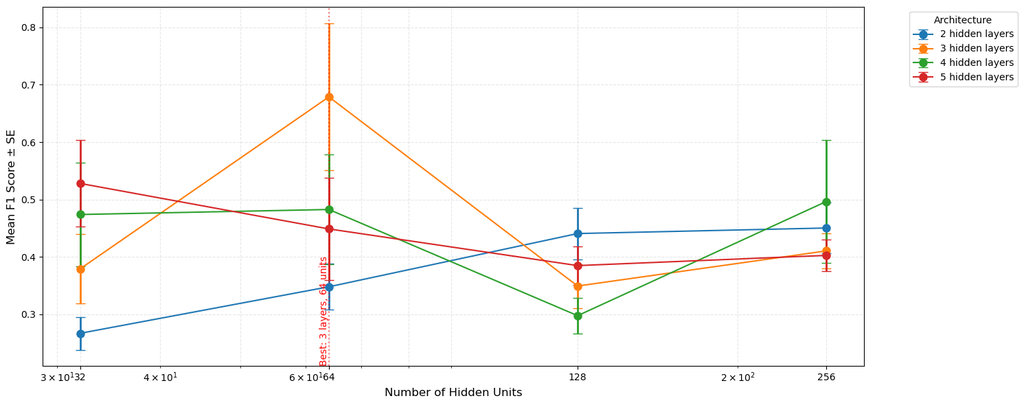

```python
num_layers_list = param_dist['num_layers']
hidden_units_list = param_dist['hidden_units']

# Create figure
plt.figure(figsize=(15, 6))

# Plot each layer configuration
for i, num_layers in enumerate(num_layers_list):
    # Extract means and standard errors
    means = nn_cv_results[i, :, 0]  # Mean F1 scores
    std_errs = nn_cv_results[i, :, 1]  # Standard errors

    plt.errorbar(
        x=hidden_units_list,
        y=means,
        yerr=std_errs,
        fmt='-o',
        label=f'{num_layers} hidden layers',
        capsize=5,
        elinewidth=2,
        markersize=8
    )

# Formatting
plt.xscale('log')
plt.xticks(hidden_units_list, labels=hidden_units_list)
plt.xlabel('Number of Hidden Units', fontsize=12)
plt.ylabel('Mean F1 Score ± SE', fontsize=12)
##plt.title('Model Performance by Architecture', fontsize=14)
plt.grid(True, which='both', linestyle='--', alpha=0.3)
plt.legend(title='Architecture', bbox_to_anchor=(1.05, 1), loc='upper left')

# Highlight best configuration
best_idx = np.unravel_index(np.argmax(nn_cv_results[:, :, 0]), nn_cv_results[:, :, 0].shape)
best_units = hidden_units_list[best_idx[1]]
best_layers = num_layers_list[best_idx[0]]
plt.axvline(x=best_units, color='red', linestyle=':', alpha=0.5)
plt.text(best_units, plt.ylim()[0],
         f'Best: {best_layers} layers, {best_units} units',
         rotation=90, va='bottom', ha='right', color='red')

plt.tight_layout()
plt.savefig('FNN_arch_weighted.png', dpi=300)
plt.show()
```

### Evaluate tuned architecture on the test data

```python
y_pred_test = balanced_model.predict(X_test).flatten() > best_prob_threshold
print(classification_report(y_test, y_pred_test))
```

```
2671/2671 ━━━━━━━━━━━━━━━━━━━━ 1s 454us/step
              precision    recall  f1-score   support

           0       1.00      1.00      1.00     85307
           1       0.78      0.85      0.81       136

    accuracy                           1.00     85443
   macro avg       0.89      0.93      0.91     85443
weighted avg       1.00      1.00      1.00     85443
```

### 4. Random Forests

```python
number_trees = 200
prob_thresholds = np.arange(0.1, 0.6, 0.05)
n_split = 5
kf  = KFold(n_splits=n_splits, random_state=42, shuffle=True)

if os.path.exists('rf_cv_results.joblib'):
    rf_cv_results = load('rf_cv_results.joblib')
else:
    rf_cv_results = np.zeros((number_trees, len(prob_thresholds), n_splits))

    for i, (train_idx, test_idx) in enumerate(kf.split(X_train, y_train)):

        X_train_fold, X_test_fold = X_train[train_idx], X_train[test_idx]
        y_train_fold, y_test_fold = y_train[train_idx], y_train[test_idx]

        rf = RandomForestClassifier(
        n_estimators=1,
        random_state=42,
        warm_start=True,
        )

        print(f'At split {i}')
        for n in range(number_trees):
            if n % 20 == 0:
                print(f'At tree {n+1}')
            rf.n_estimators = n+1 # grow n trees
            rf.fit(X_train_fold, y_train_fold)
            y_pred = rf.predict_proba(X_test_fold)[:, 1]
            prob_n_results = np.array([f1_score(y_test_fold,y_pred > p) for p in prob_thresholds])
            rf_cv_results[n,:,i] = prob_n_results

    dump(rf_cv_results, 'rf_cv_results.joblib')


means = np.mean(rf_cv_results, axis=2)
prob_index = np.argmax(means, axis=1)
means = means[np.arange(number_trees), prob_index]
stderrs = np.std(rf_cv_results, axis=2, ddof=1)[np.arange(number_trees), prob_index] / np.sqrt(n_splits)
```

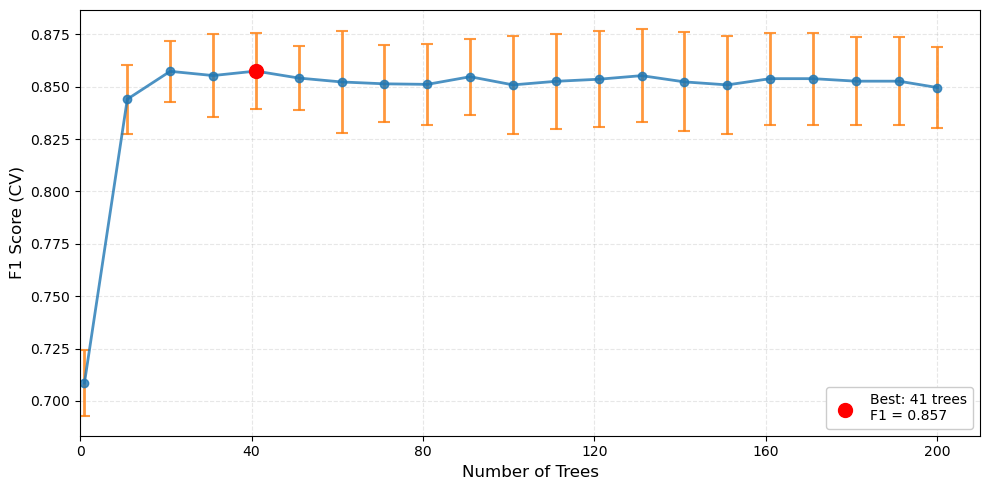

```python
tree_subset = np.arange(0, number_trees, 10)
if tree_subset[-1] != number_trees - 1:
    tree_subset = np.append(tree_subset, number_trees - 1)  # Ensure last tree is included

# Prepare data
x_values = tree_subset + 1  # Tree counts (1-based)
y_values = means[tree_subset]
y_err = stderrs[tree_subset]

# Create plot
plt.figure(figsize=(10, 5))
plt.errorbar(x_values, y_values, yerr=y_err,
             fmt='-o', color='#1f77b4',
             linewidth=2, markersize=6,
             capsize=4, capthick=1.5,
             ecolor='#ff7f0e', alpha=0.8)

# Highlight best tree count
best_idx = np.argmax(y_values)
plt.scatter(x_values[best_idx], y_values[best_idx],
            color='red', s=100, zorder=5,
            label=f'Best: {x_values[best_idx]} trees\nF1 = {y_values[best_idx]:.3f}')

# Formatting
plt.xlabel("Number of Trees", fontsize=12)
plt.ylabel("F1 Score (CV)", fontsize=12)
#plt.title("Random Forest Performance vs. Ensemble Size", fontsize=14, pad=20)
plt.xticks(np.linspace(0, number_trees, 6, dtype=int))  # Evenly spaced ticks
plt.grid(True, linestyle='--', alpha=0.3)
plt.legend(loc='lower right', framealpha=1)

# Ensure x-axis starts at 0
plt.xlim(0, None)

plt.tight_layout()
plt.savefig('RF_trees.png', dpi=300)
plt.show()
```

The chosen number of trees is a 100, since the only downside of having more trees is that it is computationally more expensive.

```python
prob_thresholds = np.arange(0.1, 0.6, 0.05)
n_split = 5
kf  = KFold(n_splits=n_splits, random_state=42, shuffle=True)

rf_cv_results = np.zeros((len(prob_thresholds), n_splits))

for i, (train_idx, test_idx) in enumerate(kf.split(X_train, y_train)):

    X_train_fold, X_test_fold = X_train[train_idx], X_train[test_idx]
    y_train_fold, y_test_fold = y_train[train_idx], y_train[test_idx]

    rf = RandomForestClassifier(
    n_estimators=100,
    random_state=42,
    n_jobs=-1
    )
    rf.fit(X_train_fold, y_train_fold)
    y_pred = rf.predict_proba(X_test_fold)[:, 1]
    rf_cv_results[:, i] = np.array([f1_score(y_test_fold, y_pred > x) for x in prob_thresholds])

means = np.mean(rf_cv_results, axis=1)
stderr = np.std(rf_cv_results, ddof=1, axis=1)/np.sqrt(n_splits)
```

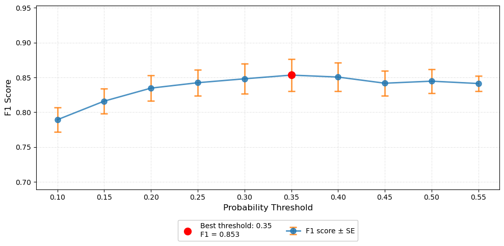

```python
plt.figure(figsize=(10, 5))

# Main plot with error bars
plt.errorbar(prob_thresholds, means, yerr=stderr,
             fmt='-o', color='#1f77b4',
             linewidth=2, markersize=8,
             capsize=5, capthick=2,
             ecolor='#ff7f0e', alpha=0.8,
             label='F1 score ± SE')

# Highlight best threshold
best_idx = np.argmax(means)
plt.scatter(prob_thresholds[best_idx], means[best_idx],
            color='red', s=100, zorder=5,
            label=f'Best threshold: {prob_thresholds[best_idx]:.2f}\nF1 = {means[best_idx]:.3f}')

# Formatting
plt.xlabel("Probability Threshold", fontsize=12)
plt.ylabel("F1 Score", fontsize=12)
#plt.title("Random Forest Performance vs. Classification Threshold", fontsize=14, pad=20)
plt.xticks(prob_thresholds)
plt.grid(True, linestyle='--', alpha=0.3)
plt.legend(loc='lower center', bbox_to_anchor=(0.5, -0.3), ncol=2, framealpha=1)

# Ensure y-axis shows full F1 range
plt.ylim(max(0, min(means)-0.1), min(1, max(means)+0.1))

plt.tight_layout()
plt.savefig('rf_thresh.png', dpi=300)
plt.show()
```

```python
best_rf_threshold = 0.35
```

#### Random Forests with balanced class weighting

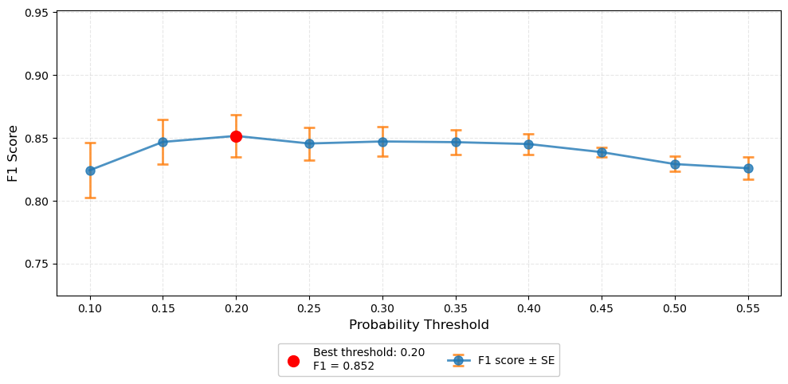

```python
prob_thresholds = np.arange(0.1, 0.6, 0.05)
n_split = 5
kf  = KFold(n_splits=n_splits, random_state=42, shuffle=True)

rf_cv_results = np.zeros((len(prob_thresholds), n_splits))

for i, (train_idx, test_idx) in enumerate(kf.split(X_train, y_train)):

    X_train_fold, X_test_fold = X_train[train_idx], X_train[test_idx]
    y_train_fold, y_test_fold = y_train[train_idx], y_train[test_idx]

    rf = RandomForestClassifier(
    n_estimators=100,
    random_state=42,
    n_jobs=-1,
    class_weight='balanced'
    )
    rf.fit(X_train_fold, y_train_fold)
    y_pred = rf.predict_proba(X_test_fold)[:, 1]
    rf_cv_results[:, i] = np.array([f1_score(y_test_fold, y_pred > x) for x in prob_thresholds])

means = np.mean(rf_cv_results, axis=1)
stderr = np.std(rf_cv_results, ddof=1, axis=1)/np.sqrt(n_splits)

plt.figure(figsize=(10, 5))

# Main plot with error bars
plt.errorbar(prob_thresholds, means, yerr=stderr,
             fmt='-o', color='#1f77b4',
             linewidth=2, markersize=8,
             capsize=5, capthick=2,
             ecolor='#ff7f0e', alpha=0.8,
             label='F1 score ± SE')

# Highlight best threshold
best_idx = np.argmax(means)
plt.scatter(prob_thresholds[best_idx], means[best_idx],
            color='red', s=100, zorder=5,
            label=f'Best threshold: {prob_thresholds[best_idx]:.2f}\nF1 = {means[best_idx]:.3f}')

# Formatting
plt.xlabel("Probability Threshold", fontsize=12)
plt.ylabel("F1 Score", fontsize=12)
#plt.title("Random Forest Performance vs. Classification Threshold", fontsize=14, pad=20)
plt.xticks(prob_thresholds)
plt.grid(True, linestyle='--', alpha=0.3)
plt.legend(loc='lower center', bbox_to_anchor=(0.5, -0.3), ncol=2, framealpha=1)

# Ensure y-axis shows full F1 range
plt.ylim(max(0, min(means)-0.1), min(1, max(means)+0.1))

plt.tight_layout()
plt.savefig('rf_weighted_thresh.png', dpi=300)
plt.show()
```

```python
rf = RandomForestClassifier(
    n_estimators=100,
    random_state=42,
    n_jobs=-1
)
rf.fit(X_train, y_train)
y_pred = rf.predict_proba(X_test)[:, 1] > best_rf_threshold
```

```python
print(classification_report(y_test, y_pred))
```

```
              precision    recall  f1-score   support

           0       1.00      1.00      1.00     85307
           1       0.85      0.85      0.85       136

    accuracy                           1.00     85443
   macro avg       0.93      0.93      0.93     85443
weighted avg       1.00      1.00      1.00     85443
```

### 5. XGBoost

```python
param_dist = {
    'learning_rate': [0.001, 0.01, 0.1],
    'max_depth': [1, 3, 6, 9],
    'subsample': [0.8, 1.0],
    'prob_thresholds': [0.05, 0.1, 0.2, 0.3, 0.4, 0.5],
    'class_weights': ['unbalanced', 'balanced'],
}

n_splits = 5
kf = KFold(n_splits=n_splits, random_state=42, shuffle=True)

def xgb_cv_results(learning_rate, max_depth, subsample, cv):

    f1_scores_fold_prob = np.zeros((n_splits, len(param_dist['prob_thresholds'])))

    for i, (train_idx, test_idx) in enumerate(kf.split(X_train, y_train)):
        X_train_fold, X_test_fold = X_train[train_idx], X_train[test_idx]
        y_train_fold, y_test_fold = y_train[train_idx], y_train[test_idx]

        if cv == 'unbalanced':
            model = xgb.XGBClassifier(
                learning_rate=learning_rate,
                max_depth=max_depth,
                subsample=subsample,
                n_estimators=500,
                random_state=42,
                early_stopping_rounds=20,
                eval_metric='logloss'
            )
        else:
            model = xgb.XGBClassifier(
                learning_rate=learning_rate,
                max_depth=max_depth,
                subsample=subsample,
                n_estimators=500,
                random_state=42,
                early_stopping_rounds=20,
                eval_metric='logloss',
                class_weights='balanced' #################################???????????????????????
            )

        model.fit(X_train_fold, y_train_fold,
                  eval_set=[(X_test_fold, y_test_fold)],
                  verbose=0)

        pred_prob = model.predict_proba(X_test_fold)[:, 1]
        f1_scores = np.array([f1_score(y_test_fold, pred_prob > x)
                            for x in param_dist['prob_thresholds']])
        f1_scores_fold_prob[i, :] = f1_scores

    # Find best threshold across folds
    mean_f1 = np.mean(f1_scores_fold_prob, axis=0)
    best_idx = np.argmax(mean_f1)

    return {
        'mean_f1': mean_f1[best_idx],
        'std_f1': np.std(f1_scores_fold_prob[:, best_idx], ddof=1) / np.sqrt(n_splits),
        'best_threshold': param_dist['prob_thresholds'][best_idx],
    }

# Main execution
best_mean = -1
if os.path.exists('xgb_cv_results.joblib'):
    results = load('xgb_cv_results.joblib')
else:
    results = None
    best_results =  None
    for lr in param_dist['learning_rate']:
        for depth in param_dist['max_depth']:
            for subsample in param_dist['subsample']:
                for cw in param_dist['class_weights']:
                    print(f"Testing lr={lr}, depth={depth}, subsample={subsample}")
                    results = xgb_cv_results(lr, depth, subsample, cw)
                    if results['mean_f1'] > best_mean:
                        best_results = results.copy()
                        best_results['learning_rate'] = lr
                        best_results['depth'] = depth
                        best_results['subsample'] = subsample
                        best_mean = results['mean_f1']
                        print(results['mean_f1'])

    dump(best_results, 'xgb_cv_results.joblib')
```

```python
results
```

```
{'mean_f1': 0.8578974974774869,
 'std_f1': 0.014415588132130047,
 'best_threshold': 0.4,
 'learning_rate': 0.1,
 'depth': 6,
 'subsample': 0.8}
```

```python
prob_thresholds = np.arange(0.1, 0.6, 0.05)
n_split = 5
kf  = KFold(n_splits=n_split, random_state=123, shuffle=True)
np.random.seed(123)
xgb_cv_results = np.zeros((len(prob_thresholds), n_split))
for i, (train_idx, test_idx) in enumerate(kf.split(X_train, y_train)):
    X_train_fold, X_test_fold = X_train[train_idx], X_train[test_idx]
    y_train_fold, y_test_fold = y_train[train_idx], y_train[test_idx]

    model_xgb = xgb.XGBClassifier(
        learning_rate=0.1,
        max_depth=6,
        subsample=0.8,
        n_estimators=500,
        random_state=42,
        early_stopping_rounds=20,
        eval_metric='logloss'
    )

    model_xgb.fit(X_train_fold, y_train_fold,
            eval_set=[(X_test_fold, y_test_fold)],
            verbose=0)

    pred_prob = model_xgb.predict_proba(X_test_fold)[:, 1]
    xgb_cv_results[:, i] = np.array([f1_score(y_test_fold, pred_prob > x) for x in prob_thresholds])

means = np.mean(xgb_cv_results, axis=1)
stderr = np.std(xgb_cv_results, ddof=1, axis=1)/np.sqrt(n_splits)
```

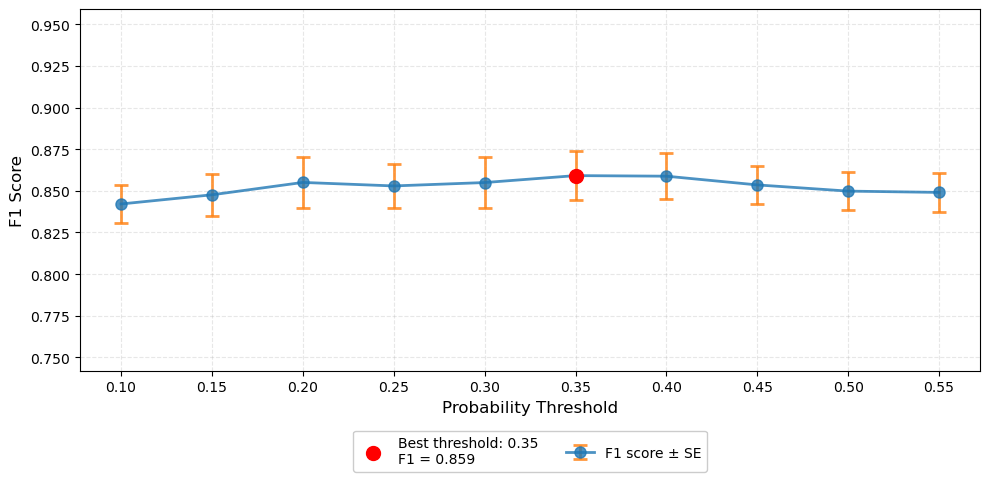

```python
plt.figure(figsize=(10, 5))

# Main plot with error bars
plt.errorbar(prob_thresholds, means, yerr=stderr,
             fmt='-o', color='#1f77b4',
             linewidth=2, markersize=8,
             capsize=5, capthick=2,
             ecolor='#ff7f0e', alpha=0.8,
             label='F1 score ± SE')

# Highlight best threshold
best_idx = np.argmax(means)
plt.scatter(prob_thresholds[best_idx], means[best_idx],
            color='red', s=100, zorder=5,
            label=f'Best threshold: {prob_thresholds[best_idx]:.2f}\nF1 = {means[best_idx]:.3f}')

# Formatting
plt.xlabel("Probability Threshold", fontsize=12)
plt.ylabel("F1 Score", fontsize=12)
#plt.title("XGBoost Performance vs. Classification Threshold", fontsize=14, pad=20)
plt.xticks(prob_thresholds)
plt.grid(True, linestyle='--', alpha=0.3)
plt.legend(loc='lower center', bbox_to_anchor=(0.5, -0.3), ncol=2, framealpha=1)

# Ensure y-axis shows full F1 range
plt.ylim(max(0, min(means)-0.1), min(1, max(means)+0.1))

plt.tight_layout()
plt.savefig('xgboost.png', dpi=300)
plt.show()
```

```python
pred_prob_test = model_xgb.predict_proba(X_test)[:, 1] > 0.35
print(classification_report(y_test, pred_prob_test))
```

```
              precision    recall  f1-score   support

           0       1.00      1.00      1.00     85307
           1       0.94      0.82      0.88       136

    accuracy                           1.00     85443
   macro avg       0.97      0.91      0.94     85443
weighted avg       1.00      1.00      1.00     85443
```

## 4. Stacking XGBoost and Feed Forward Neural Network and Random Forest

```python
np.random.seed(123)
n_splits_level_0 = 10
kf_level_0 = KFold(n_splits=n_splits_level_0, random_state=42, shuffle=True)

def train_nn(X_train_fold, X_test_fold, y_train_fold, y_test_fold, num_layers=1, num_units=32, learning_rate=0.001):
    model = Sequential()
    for _ in range(num_layers):
        model.add(Dense(num_units, activation='relu'))
    model.add(Dense(1, activation='sigmoid'))
    optimizer = Adam(learning_rate=learning_rate)
    model.compile(optimizer=optimizer,
                    loss='binary_crossentropy',
                    metrics=['accuracy'])

    early_stopping = EarlyStopping(
        monitor='val_loss',
        patience=5,                 # number of epochs with no improvement
        restore_best_weights=True,
        min_delta=0.0001,           # minimum change to quantify improvement
        mode='min'                  # lower loss is better
    )

    model.fit(
        X_train_fold, y_train_fold,
        validation_data = (X_test_fold, y_test_fold),
        epochs=100,
        batch_size=64,
        callbacks=[early_stopping],
        verbose=0
    )
    return model

def train_XGBoost(X_train_fold, X_test_fold, y_train_fold, y_test_fold, learning_rate=0.1, max_depth=6, subsample=0.8):
    model = xgb.XGBClassifier(
            learning_rate=learning_rate,
            max_depth=max_depth,
            subsample=subsample,
            n_estimators=500,
            random_state=42,
            early_stopping_rounds=20,
            eval_metric='logloss'
        )

    model.fit(X_train_fold, y_train_fold,
                eval_set=[(X_test_fold, y_test_fold)],
                verbose=0)

    return model

def train_RF(X_train_fold, y_train_fold):
    model = RandomForestClassifier(
        n_estimators=100,
        random_state=42,
    )
    model.fit(X_train_fold, y_train_fold)
    return model

def process_fold(train_idx, test_idx, X_train, y_train):
    X_train_fold, X_test_fold = X_train[train_idx], X_train[test_idx]
    y_train_fold, y_test_fold = y_train[train_idx], y_train[test_idx]

    # Train NN and XGBoost and Random Forest in parallel
    nn = train_nn(X_train_fold, X_test_fold, y_train_fold, y_test_fold)
    xgb_model = train_XGBoost(X_train_fold, X_test_fold, y_train_fold, y_test_fold)
    rf_model = train_RF(X_train_fold, y_train_fold)

    # Get predictions
    nn_pred = nn.predict(X_test_fold).flatten()
    xgb_pred = xgb_model.predict_proba(X_test_fold)[:, 1]
    rf_pred = rf_model.predict_proba(X_test_fold)[:, 1]

    # Avoid division by zero in log-odds
    epsilon = 1e-6
    nn_pred = np.clip(nn_pred, epsilon, 1 - epsilon)
    xgb_pred = np.clip(xgb_pred, epsilon, 1 - epsilon)
    rf_pred = np.clip(rf_pred, epsilon, 1-epsilon)

    log_odds_nn = np.log(nn_pred / (1 - nn_pred))
    log_odds_xgb = np.log(xgb_pred / (1 - xgb_pred))
    log_odds_rf = np.log(rf_pred / (1 - rf_pred))

    return test_idx, log_odds_nn, log_odds_xgb, log_odds_rf


if os.path.exists('stack_results.joblib'):
    X_train_new_features = load('stack_results.joblib')
else:
    # obtain the new out of fold features
    # Parallelize fold processing
    results = Parallel(n_jobs=-1)(
        delayed(process_fold)(train_idx, test_idx, X_train, y_train)
        for train_idx, test_idx in kf_level_0.split(X_train, y_train)
    )

    X_train_new_features = np.zeros(shape=(X_train.shape[0], 3))
    for test_idx, log_odds_nn, log_odds_xgb, log_odds_rf in results:
        X_train_new_features[test_idx, 0] = log_odds_nn
        X_train_new_features[test_idx, 1] = log_odds_xgb
        X_train_new_features[test_idx, 2] = log_odds_rf

    dump(X_train_new_features, 'stack_results.joblib')
```

```python
x_vals = X_train_new_features[:,0]
y_vals = X_train_new_features[:,1]
z_vals = X_train_new_features[:,2]
labels = y_train

# Colour and opacity
colors = np.where(labels == 1, 'rgba(220, 20, 60, 0.6)', 'rgba(0, 0, 128, 0.6)')  # Crimson / Navy with alpha

# Create scatter trace
fig = go.Figure(data=[go.Scatter3d(
    x=x_vals, y=y_vals, z=z_vals,
    mode='markers',
    marker=dict(
        size=5,
        color=colors,
        line=dict(width=0),
        opacity=0.6
    )
)])


fig.update_layout(
    title=dict(text='New Features showing class seperation', x=0.5, font=dict(size=18)),
    scene=dict(
        xaxis=dict(title='X1', showgrid=True, gridcolor='lightgrey', zeroline=False),
        yaxis=dict(title='X2', showgrid=True, gridcolor='lightgrey', zeroline=False),
        zaxis=dict(title='X3', showgrid=True, gridcolor='lightgrey', zeroline=False),
        bgcolor='white',
        aspectmode='cube'
    ),
    margin=dict(l=0, r=0, t=40, b=0),
    showlegend=False,
    width=750,
    height=600
)

fig.show()
```

[output not shown]

```python
np.sum(np.isinf(X_train_new_features))
```

```
0
```

```python
n_splits = 5
kf = KFold(n_splits=n_splits, random_state=42, shuffle=True)
prob_thresholds = np.arange(0.05, 0.6, 0.05)

def evaluate_threshold(prob, X_train, y_train):
    cv_result = np.zeros((n_splits,))
    for i, (train_idx, test_idx) in enumerate(kf.split(X_train, y_train)):
        X_train_fold, X_test_fold = X_train[train_idx], X_train[test_idx]
        y_train_fold, y_test_fold = y_train[train_idx], y_train[test_idx]

        lr = LogisticRegression()
        lr.fit(X_train_fold, y_train_fold)
        cv_result[i] = f1_score(y_test_fold, lr.predict_proba(X_test_fold)[:,1] > prob)

    return np.mean(cv_result), np.std(cv_result, ddof=1)/np.sqrt(n_splits)

# Parallel execution
results = Parallel(n_jobs=-1)(
    delayed(evaluate_threshold)(prob, X_train_new_features, y_train)
    for prob in prob_thresholds
)

# Unpack results
means, std = zip(*results)
means = np.array(means)
std = np.array(std)
```

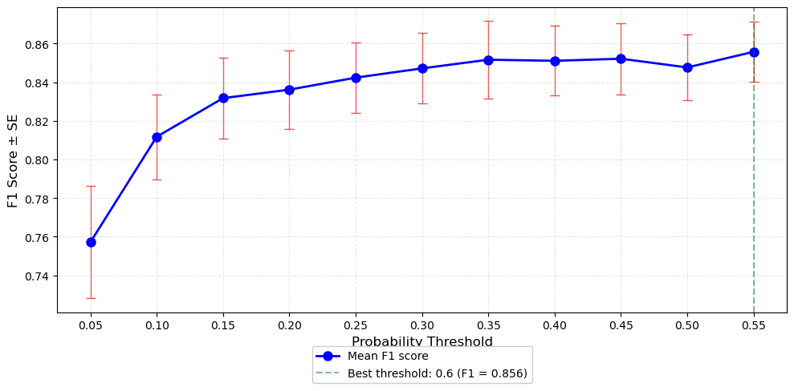

```python
plt.figure(figsize=(10, 5))

# Plot main line with points
plt.plot(prob_thresholds, means, 'o-', color='b', linewidth=2,
         markersize=8, label='Mean F1 score', zorder=2)

# Add error bars (standard error)
plt.errorbar(prob_thresholds, means, yerr=std, fmt='none',
             ecolor='red', elinewidth=1, capsize=4, alpha=0.7, zorder=1)

# Formatting
plt.xlabel('Probability Threshold', fontsize=12)
plt.ylabel('F1 Score ± SE', fontsize=12)
#plt.title('F1 Score vs. Classification Threshold (5-fold CV)', fontsize=14)
plt.grid(True, linestyle='--', alpha=0.3)

# Highlight best threshold
best_idx = np.argmax(means)
best_thresh = prob_thresholds[best_idx]
best_score = means[best_idx]

# Add dashed line at best threshold
plt.axvline(x=best_thresh, color='g', linestyle='--', alpha=0.5,
            label=f'Best threshold: {best_thresh:.1f} (F1 = {best_score:.3f})')

plt.xticks(prob_thresholds)  # Show all tested thresholds
plt.legend(loc='lower center', bbox_to_anchor=(0.5, -0.25), framealpha=1)
plt.tight_layout()
plt.savefig('stacking_thresh.png', dpi=300)
plt.show()
```

#### Finally we obtain the precision, recall and F1-score on the test data. To do this the three base models are trained on 90% of the training data, where the remaining 10% are used for early stopping for the XGBoost and Neural Network. The log odds of the test data are obtained for these models. Then the logistic regression model trained on the training data along with derived features obtained previously are obtained and used the predictions of the base models on the test data to obtain final predictions.

```python
np.random.seed(123)
stack_X_train_train, stack_X_train_test, stack_y_train_train, stack_y_train_test = train_test_split(X_train, y_train, test_size=0.1, random_state=42)

nn = train_nn(stack_X_train_train, stack_X_train_test, stack_y_train_train, stack_y_train_test)
xgb_model = train_XGBoost(stack_X_train_train, stack_X_train_test, stack_y_train_train, stack_y_train_test)
rf_model = train_RF(stack_X_train_train, stack_y_train_train)

# Get predictions
nn_pred = nn.predict(X_test).flatten()
xgb_pred = xgb_model.predict_proba(X_test)[:, 1]
rf_pred = rf_model.predict_proba(X_test)[:, 1]

# Avoid division by zero in log-odds
epsilon = 1e-6
nn_pred = np.clip(nn_pred, epsilon, 1 - epsilon)
xgb_pred = np.clip(xgb_pred, epsilon, 1 - epsilon)
rf_pred = np.clip(rf_pred, epsilon, 1-epsilon)

log_odds_nn = np.log(nn_pred / (1 - nn_pred)).reshape(-1, 1)
log_odds_xgb = np.log(xgb_pred / (1 - xgb_pred)).reshape(-1, 1)
log_odds_rf = np.log(rf_pred / (1 - rf_pred)).reshape(-1, 1)

X_test_stack = np.c_[log_odds_nn, log_odds_xgb, log_odds_rf]

lr = LogisticRegression(random_state=42)
lr.fit(X_train_new_features, y_train)

final_stack_predictions = lr.predict(X_test_stack)  # using probability threshold 0.5
```

```
2671/2671 ━━━━━━━━━━━━━━━━━━━━ 2s 560us/step
```

```python
print(classification_report(y_test, final_stack_predictions))
```

```
              precision    recall  f1-score   support

           0       1.00      1.00      1.00     85307
           1       0.95      0.82      0.88       136

    accuracy                           1.00     85443
   macro avg       0.97      0.91      0.94     85443
weighted avg       1.00      1.00      1.00     85443
```